# Committee Meeting 12-11

Hannah Andrews

12/8/2020

A little guidance for the following…

Dataset: Midlife in the United States (MIDUS). There are three waves, denoted MIDUS1, MIDUS2, and MIDUS3.

Variables: DV: Use of completementary and alternative medicine (CAM). There are dummies for each of 15 CAM modalities indicating any use in the past year, and a summed index that represents the number of CAMs used in the past year. TBD: Latent classes (LCA) and factors. I spent about a week on LCA and have some output we can look over, but it became clear I would need more time to come up with a class structure I was confident in.

IVs: Income, education, gender, and race.

This document is organized into three sections: single variable distributions (CAM dummies, CAM summed index, income, education, gender, and race), bivariate distributions (CAM summed index by each IV), and missing case patterns.

# Variable Distributions

## Complementary and Alternative Medicines (CAMs)

## CAM Dummies: Have you used any of the following CAMs in the past year?

### MIDUS 1 Indiviudal CAMs

```
## MIDUS1_recode[camslist]
##
##  15  Variables      7108  Observations
## --------------------------------------------------------------------------------
## aCamEverAcupuncture
##        n  missing distinct
##     6279      829        2
##
## Value         No   Yes
## Frequency   6198    81
## Proportion 0.987 0.013
## --------------------------------------------------------------------------------
## aCamEverBiofeedback
##        n  missing distinct
##     6272      836        2
##
## Value         No   Yes
## Frequency   6224    48
## Proportion 0.992 0.008
## --------------------------------------------------------------------------------
## aCamEverChiropractor
##        n  missing distinct
##     6282      826        2
##
## Value        No  Yes
## Frequency  5523  759
## Proportion 0.88 0.12
## --------------------------------------------------------------------------------
## aCamEverEnergy
##        n  missing distinct
##     6271      837        2
##
## Value         No   Yes
## Frequency   6180    91
## Proportion 0.985 0.015
## --------------------------------------------------------------------------------
## aCamEverMoveTherapy
##        n  missing distinct
##     6275      833        2
##
```

[output cut: 69 more lines]

```
##        n  missing distinct
##     6279      829        2
##
## Value        No  Yes
## Frequency  5591  688
## Proportion 0.89 0.11
## --------------------------------------------------------------------------------
## aCamEverSpiritHeal
##        n  missing distinct
##     6266      842        2
##
## Value         No   Yes
## Frequency   6060   206
## Proportion 0.967 0.033
## --------------------------------------------------------------------------------
```

### MIDUS 2 Individual CAMs

```
## MIDUS2_recode[camslist]
##
##  15  Variables      7354  Observations
## --------------------------------------------------------------------------------
## bCamEverAcupuncture
##        n  missing distinct
##     3980     3374        2
##
## Value         No   Yes
## Frequency   3898    82
## Proportion 0.979 0.021
## --------------------------------------------------------------------------------
## bCamEverBiofeedback
##        n  missing distinct
##     3969     3385        2
##
## Value         No   Yes
## Frequency   3932    37
## Proportion 0.991 0.009
## --------------------------------------------------------------------------------
## bCamEverChiropractor
##        n  missing distinct
##     3981     3373        2
##
## Value        No  Yes
## Frequency  3302  679
## Proportion 0.83 0.17
## --------------------------------------------------------------------------------
## bCamEverEnergy
##        n  missing distinct
##     3956     3398        2
##
## Value         No   Yes
## Frequency   3860    96
## Proportion 0.976 0.024
## --------------------------------------------------------------------------------
## bCamEverMoveTherapy
##        n  missing distinct
##     3973     3381        2
##
```

[output cut: 69 more lines]

```
##        n  missing distinct
##     3969     3385        2
##
## Value         No   Yes
## Frequency   3801   168
## Proportion 0.958 0.042
## --------------------------------------------------------------------------------
## bCamEverSpiritHeal
##        n  missing distinct
##     3972     3382        2
##
## Value         No   Yes
## Frequency   3765   207
## Proportion 0.948 0.052
## --------------------------------------------------------------------------------
```

### MIDUS 3 Individual CAMs

```
## MIDUS3_recode[camslist]
##
##  15  Variables      7108  Observations
## --------------------------------------------------------------------------------
## cCamEverAcupuncture
##        n  missing distinct
##     2867     4241        2
##
## Value         No   Yes
## Frequency   2763   104
## Proportion 0.964 0.036
## --------------------------------------------------------------------------------
## cCamEverBiofeedback
##        n  missing distinct
##     2857     4251        2
##
## Value         No   Yes
## Frequency   2823    34
## Proportion 0.988 0.012
## --------------------------------------------------------------------------------
## cCamEverChiropractor
##        n  missing distinct
##     2874     4234        2
##
## Value        No  Yes
## Frequency  2367  507
## Proportion 0.82 0.18
## --------------------------------------------------------------------------------
## cCamEverEnergy
##        n  missing distinct
##     2840     4268        2
##
## Value         No   Yes
## Frequency   2765    75
## Proportion 0.974 0.026
## --------------------------------------------------------------------------------
## cCamEverMoveTherapy
##        n  missing distinct
##     2865     4243        2
##
```

[output cut: 69 more lines]

```
##        n  missing distinct
##     2860     4248        2
##
## Value         No   Yes
## Frequency   2685   175
## Proportion 0.939 0.061
## --------------------------------------------------------------------------------
## cCamEverSpiritHeal
##        n  missing distinct
##     2858     4250        2
##
## Value         No   Yes
## Frequency   2710   148
## Proportion 0.948 0.052
## --------------------------------------------------------------------------------
```

### MIDUS 1 CAM Summed Index

```
##    Min. 1st Qu.  Median    Mean 3rd Qu.    Max.    NA's
##       2      16      17      17      18      32     814
```

```
##       median         mean      SE.mean CI.mean.0.95          var      std.dev
##       17.000       17.104        0.023        0.044        3.206        1.791
##     coef.var
##        0.105
```

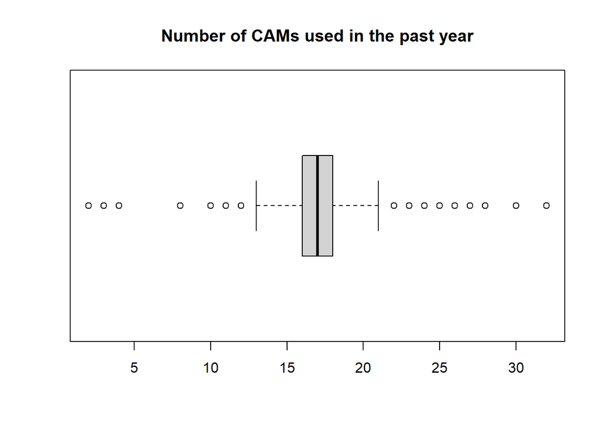

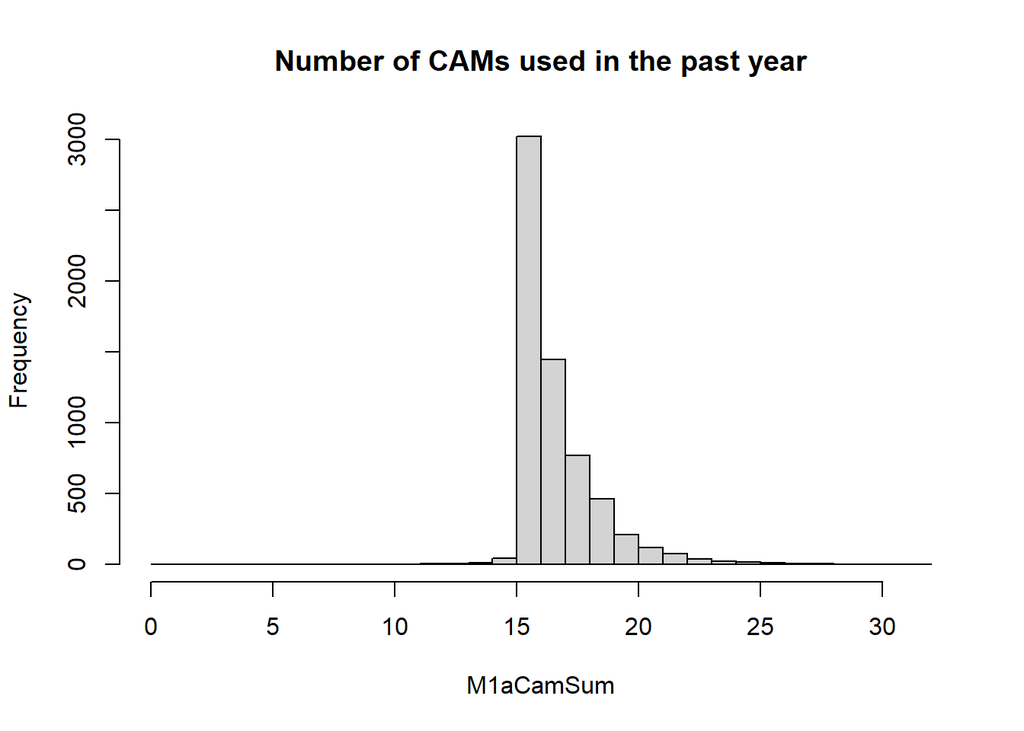

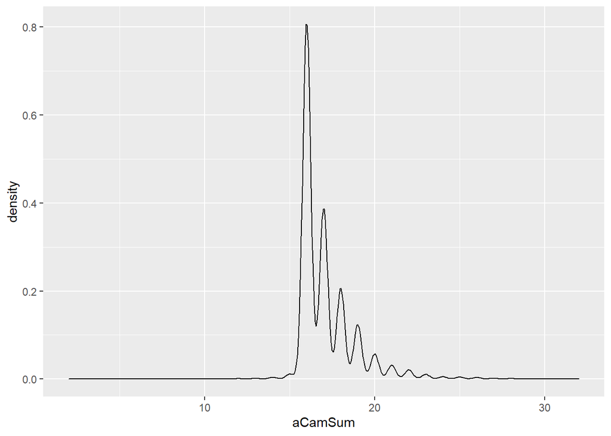

### MIDUS 2 CAM Summed Index

```
##    Min. 1st Qu.  Median    Mean 3rd Qu.    Max.    NA's
##       1      16      17      17      18      31    3342
```

```
##       median         mean      SE.mean CI.mean.0.95          var      std.dev
##       17.000       17.432        0.038        0.074        5.689        2.385
##     coef.var
##        0.137
```

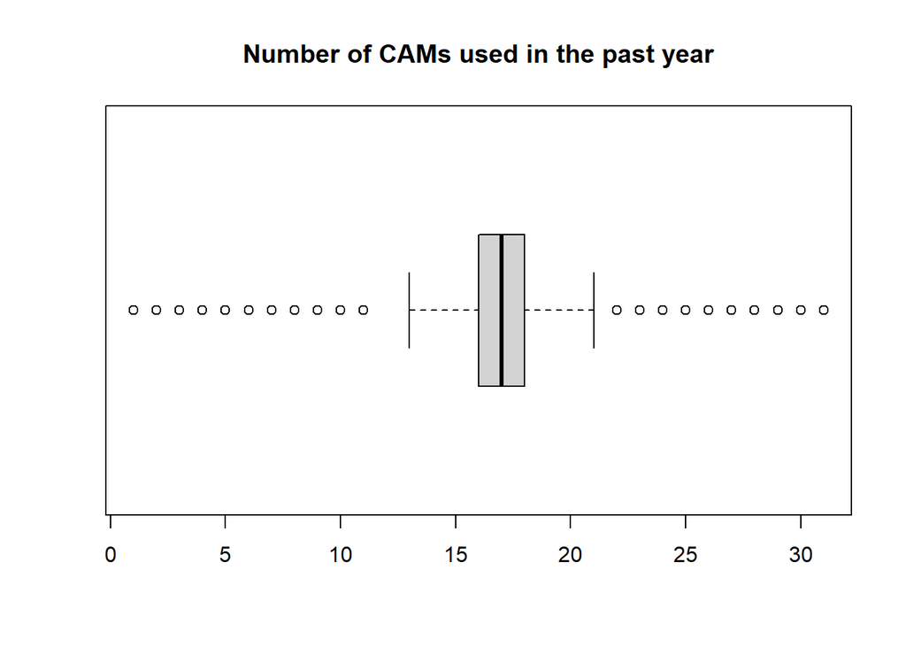

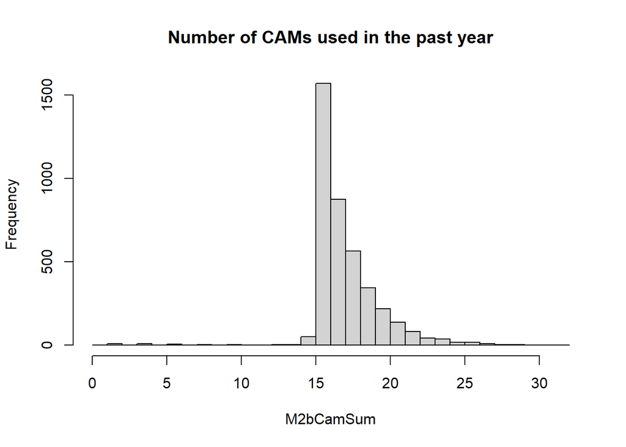

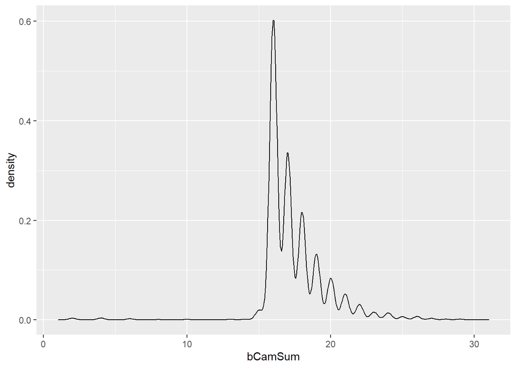

### MIDUS 3 CAM Summed Index

```
## MIDUS3_recode$cCamSum
##        n  missing distinct     Info     Mean      Gmd      .05      .10
##     2899     4209       27    0.927    17.42    2.329       16       16
##      .25      .50      .75      .90      .95
##       16       17       18       20       22
##
## lowest :  1  2  4  6  8, highest: 28 29 30 31 32
```

```
##       median         mean      SE.mean CI.mean.0.95          var      std.dev
##       17.000       17.419        0.048        0.094        6.733        2.595
##     coef.var
##        0.149
```

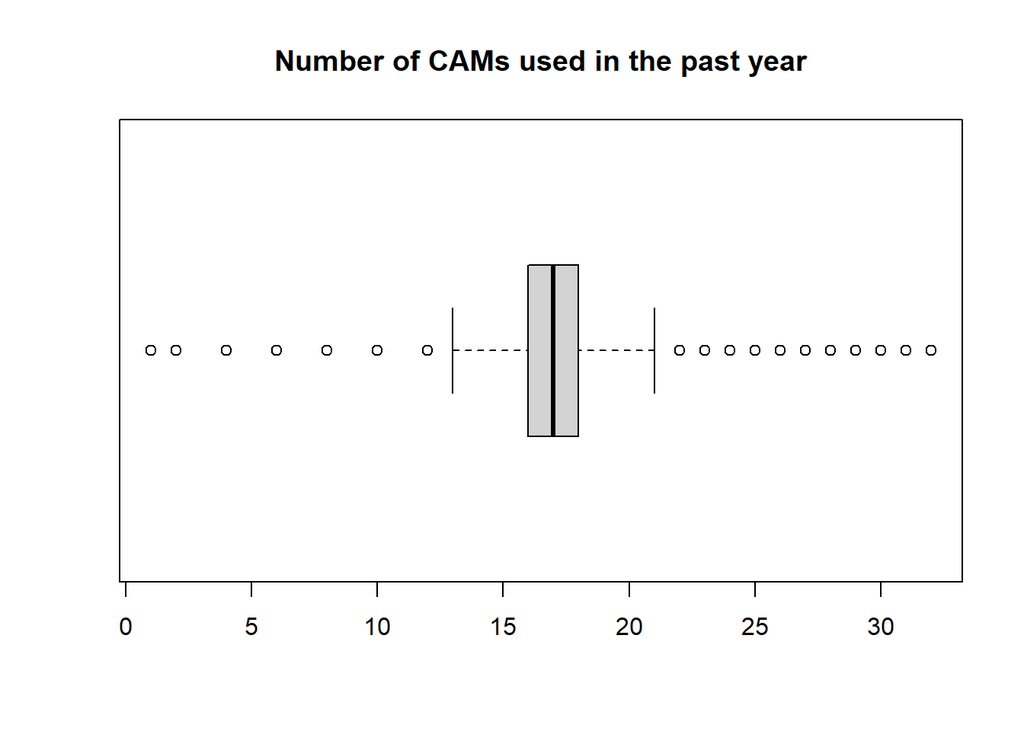

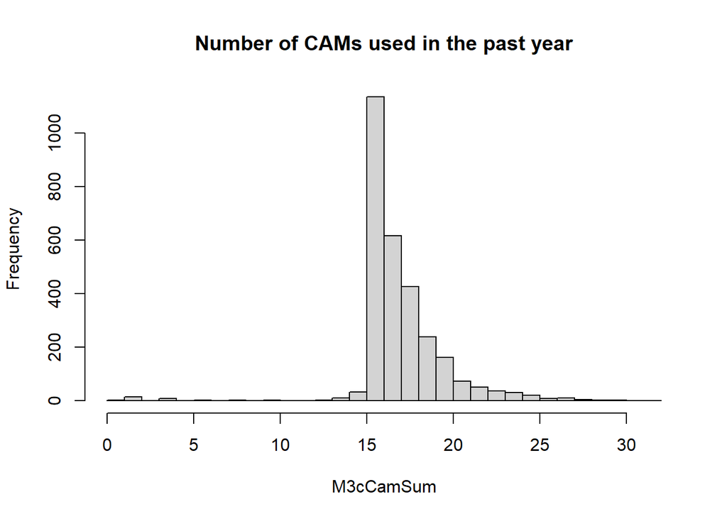

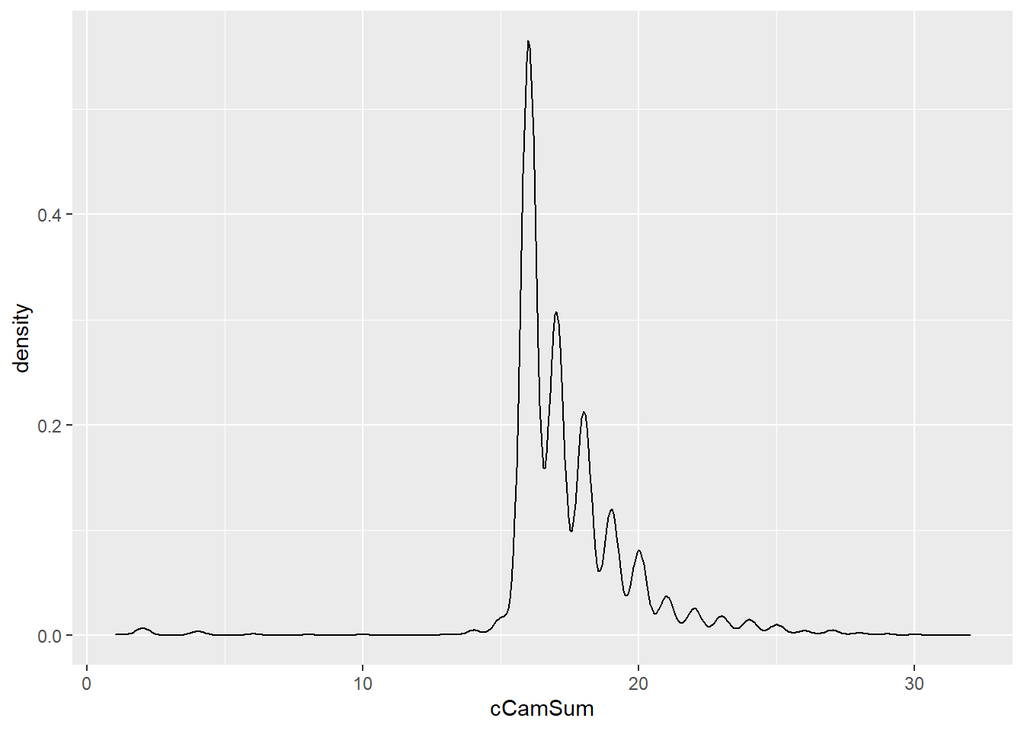

## Income

### MIDUS 1 Household Income

```
##    Min. 1st Qu.  Median    Mean 3rd Qu.    Max.    NA's
##       0   29000   55000   73380   95000  300000     998
```

```
##        median          mean       SE.mean  CI.mean.0.95           var
##      55000.00      73379.62        830.03       1627.15 4209495124.10
##       std.dev      coef.var
##      64880.62          0.88
```

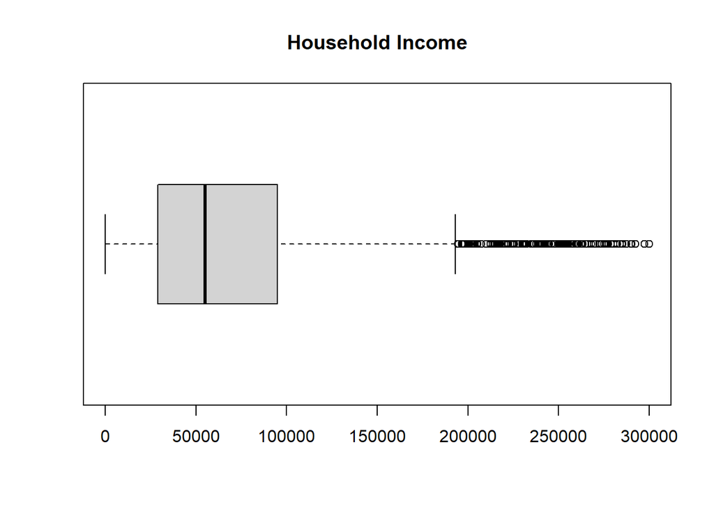

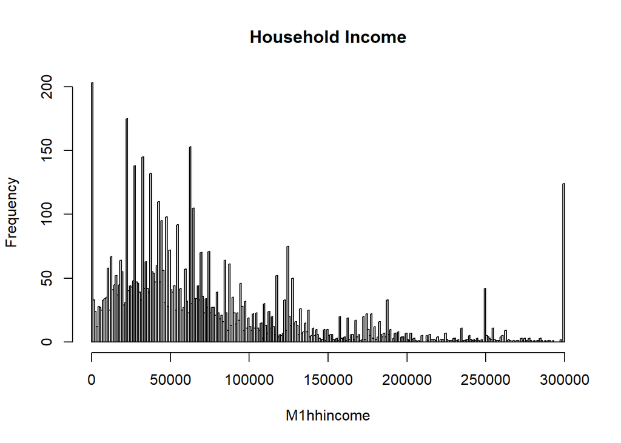

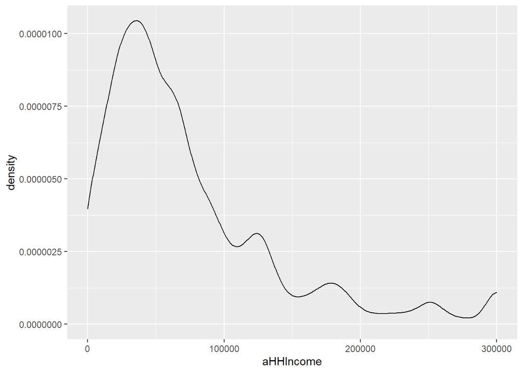

### MIDUS 2 Household Income

```
##    Min. 1st Qu.  Median    Mean 3rd Qu.    Max.    NA's
##       0   29000   57500   71364   95443  300000    3500
```

```
##                          x
## median            57500.00
## mean              71363.52
## SE.mean             973.95
## CI.mean.0.95       1909.51
## var          3655822857.30
## std.dev           60463.40
## coef.var              0.85
```

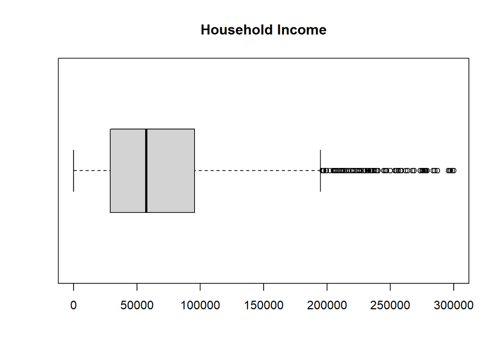

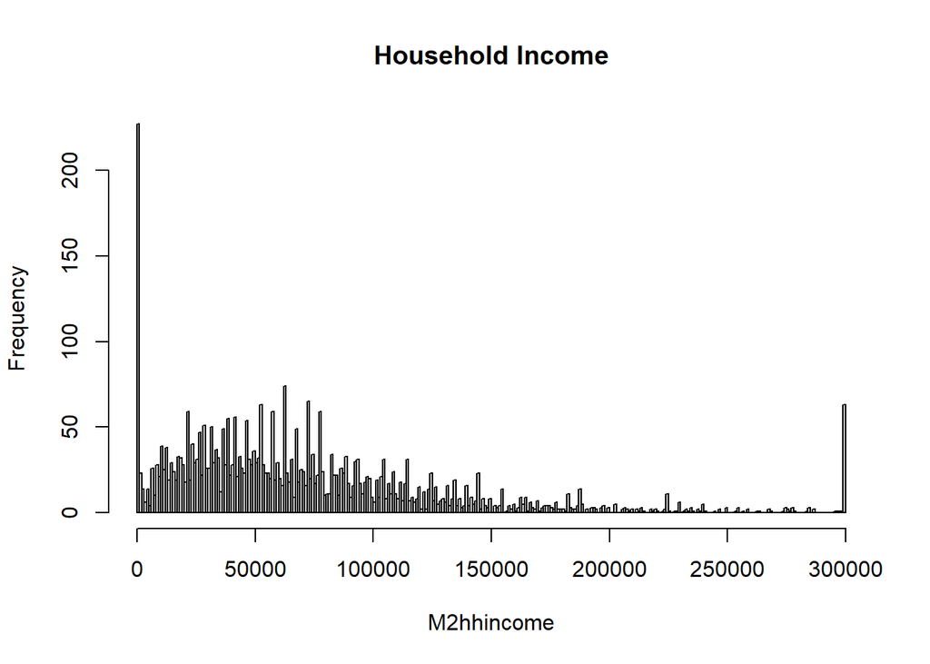

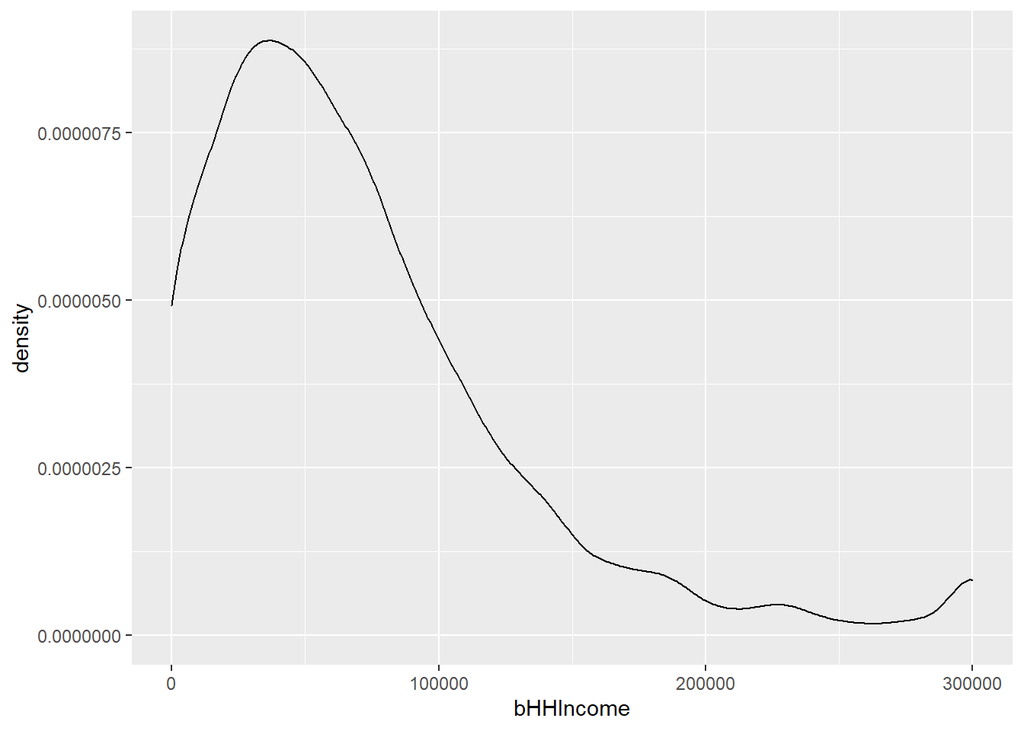

### MIDUS 3 Household Income

```
##    Min. 1st Qu.  Median    Mean 3rd Qu.    Max.    NA's
##       0   34000   68000   87920  121250  300000    4396
```

```
##                          x
## median            68000.00
## mean              87919.71
## SE.mean            1421.75
## CI.mean.0.95       2787.82
## var          5481942578.04
## std.dev           74040.14
## coef.var              0.84
```

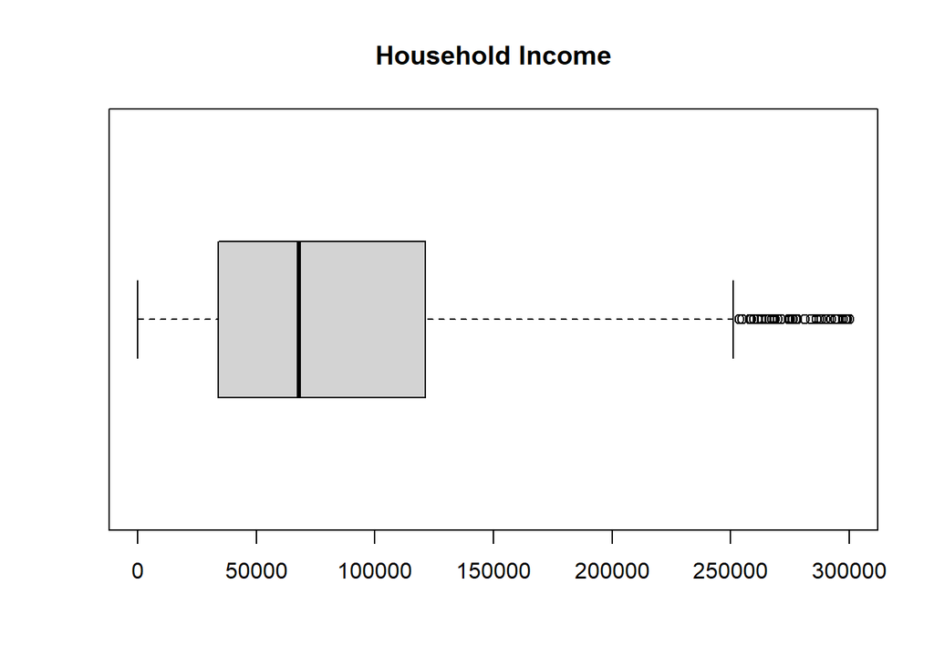

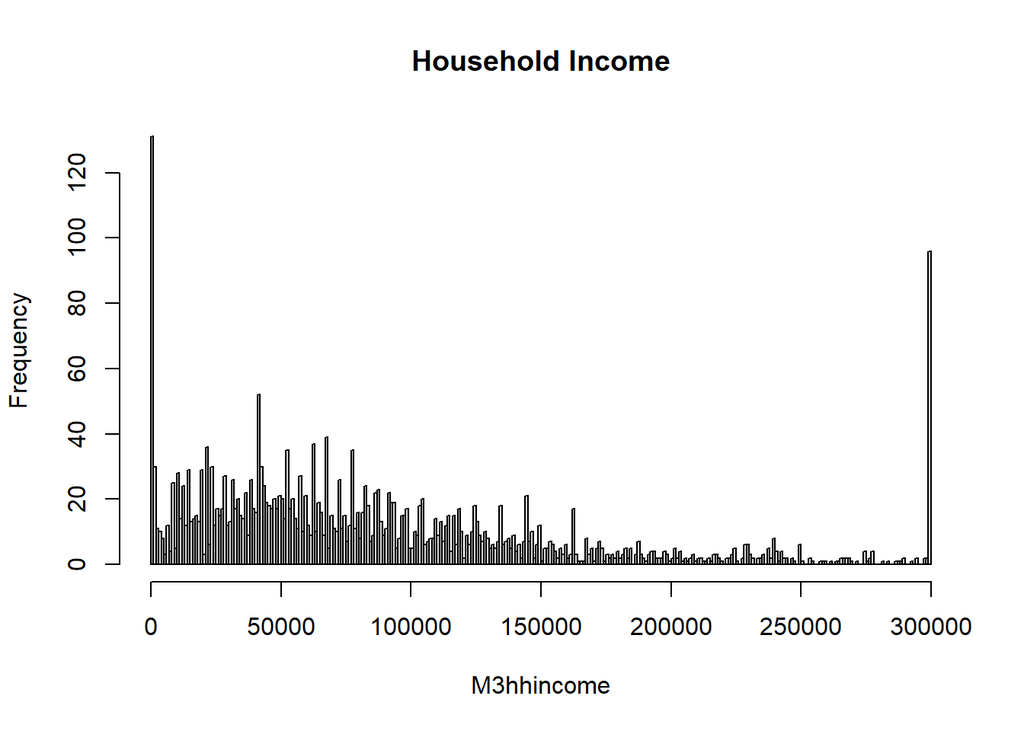

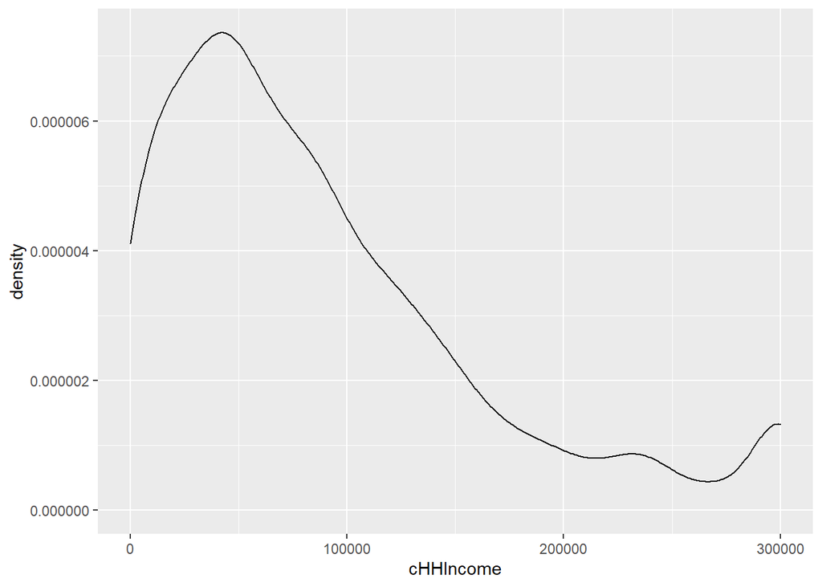

## Education

### MIDUS 1 Education

```
##
##                                       Less than High School
##                                                         681
##                                          High School or GED
##                                                        2060
## Some college/Associates/2-year college or vocational school
##                                                        2173
##                                                   Bachelors
##                                                        1437
##                             Graduate or Professional Degree
##                                                         744
##                                                        <NA>
##                                                          13
```

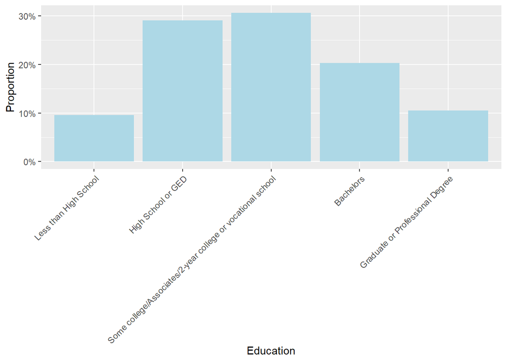

### MIDUS 2 Education

```
##
##                                       Less than High School
##                                                         309
##                                          High School or GED
##                                                        1327
## Some college/Associates/2-year college or vocational school
##                                                        1484
##                                                   Bachelors
##                                                        1109
##                             Graduate or Professional Degree
##                                                         727
##                                                        <NA>
##                                                        2398
```

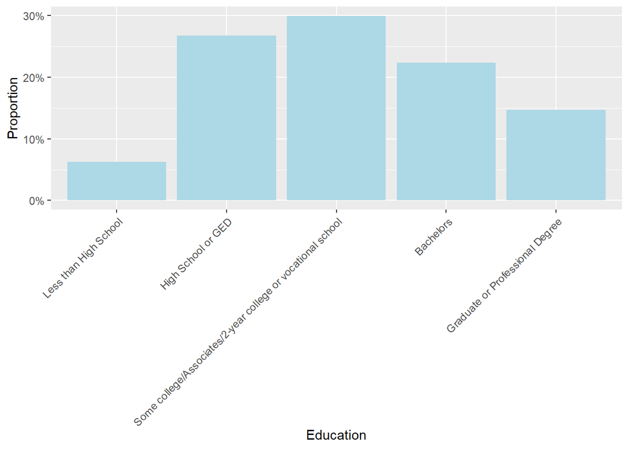

### MIDUS 3 Education

```
##
##                                       Less than High School
##                                                         170
##                                          High School or GED
##                                                         785
## Some college/Associates/2-year college or vocational school
##                                                         953
##                                                   Bachelors
##                                                         794
##                             Graduate or Professional Degree
##                                                         581
##                                                        <NA>
##                                                        3825
```

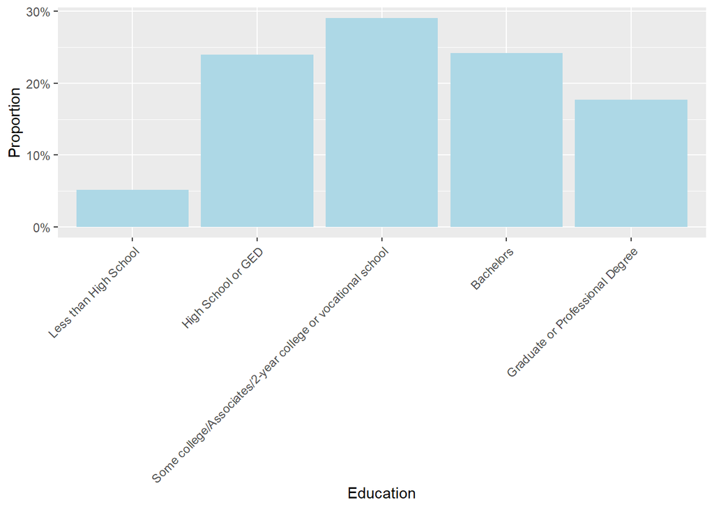

## Gender

### MIDUS 1 Gender

```
## MIDUS1_recode$aGender
##        n  missing distinct
##     7106        2        2
##
## Value        (1) Male (2) Female
## Frequency        3440       3666
## Proportion       0.48       0.52
```

### MIDUS 2 Gender

```
## MIDUS2_recode$bGender
##        n  missing distinct
##     4963     2391        2
##
## Value        (1) MALE (2) FEMALE
## Frequency        2316       2647
## Proportion       0.47       0.53
```

### MIDUS 3 Gender

```
## MIDUS3_recode$cGender
##        n  missing distinct
##     3294     3814        2
##
## Value        (1) MALE (2) FEMALE
## Frequency        1484       1810
## Proportion       0.45       0.55
```

## Race and Ethnicity

### MIDUS 1 Race and Ethnicity

```
##
## White Black Other  <NA>
##  5600   321   255   932
```

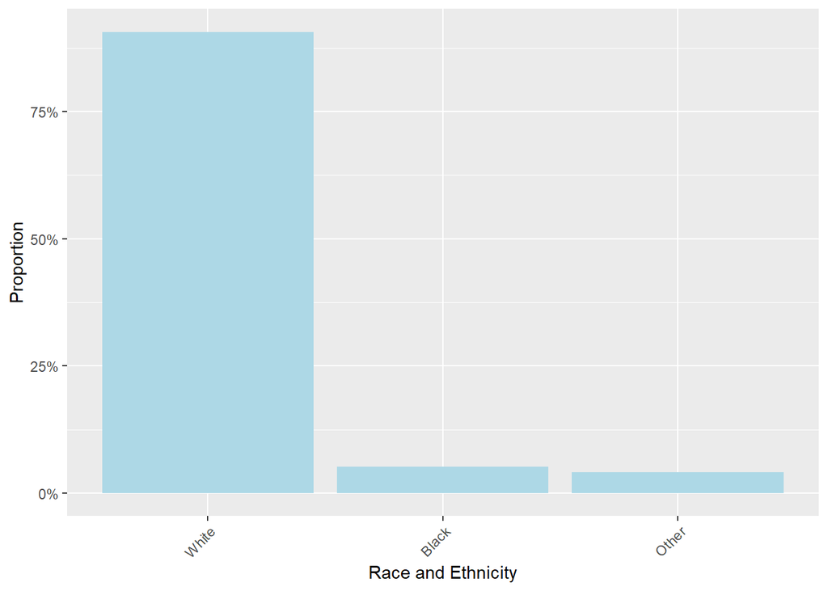

### MIDUS 2 Race and Ethnicity

```
##
## Non-Hispanic White Non-Hispanic Black           Hispanic              Other
##               4392                225                151                164
##               <NA>
##               2422
```

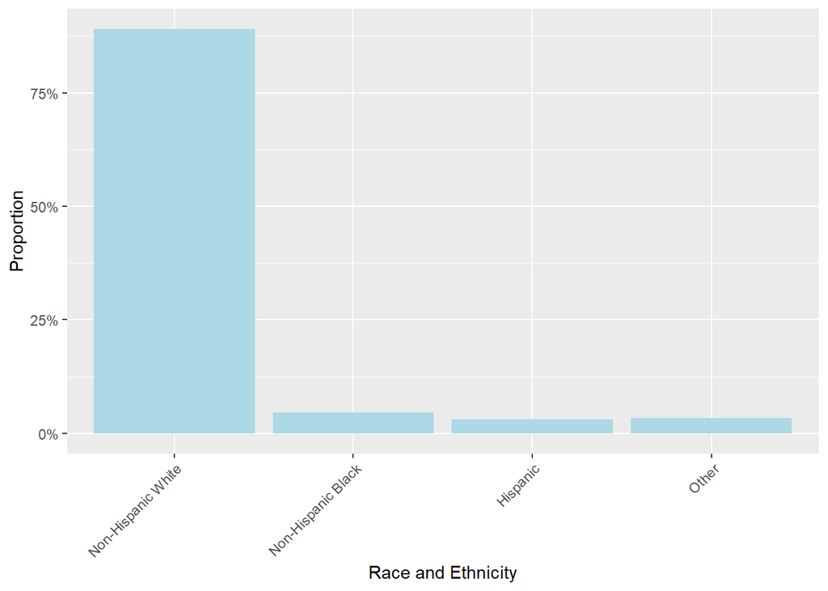

### MIDUS 3 Race and Ethnicity

```
##
## Non-Hispanic White Non-Hispanic Black           Hispanic              Other
##               2853                121                 98                191
##               <NA>
##               3845
```

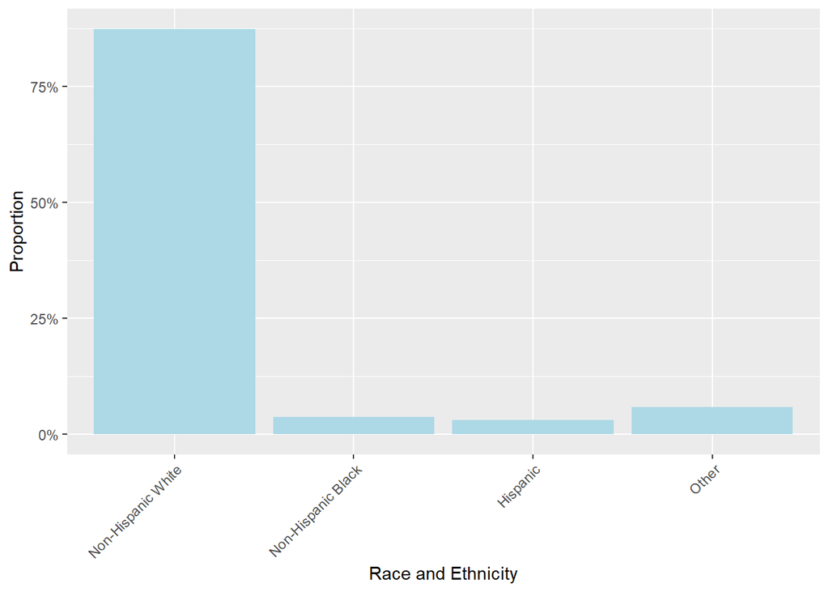

# Bivariate Distributions

## Income and CAMs

### MIDUS 1

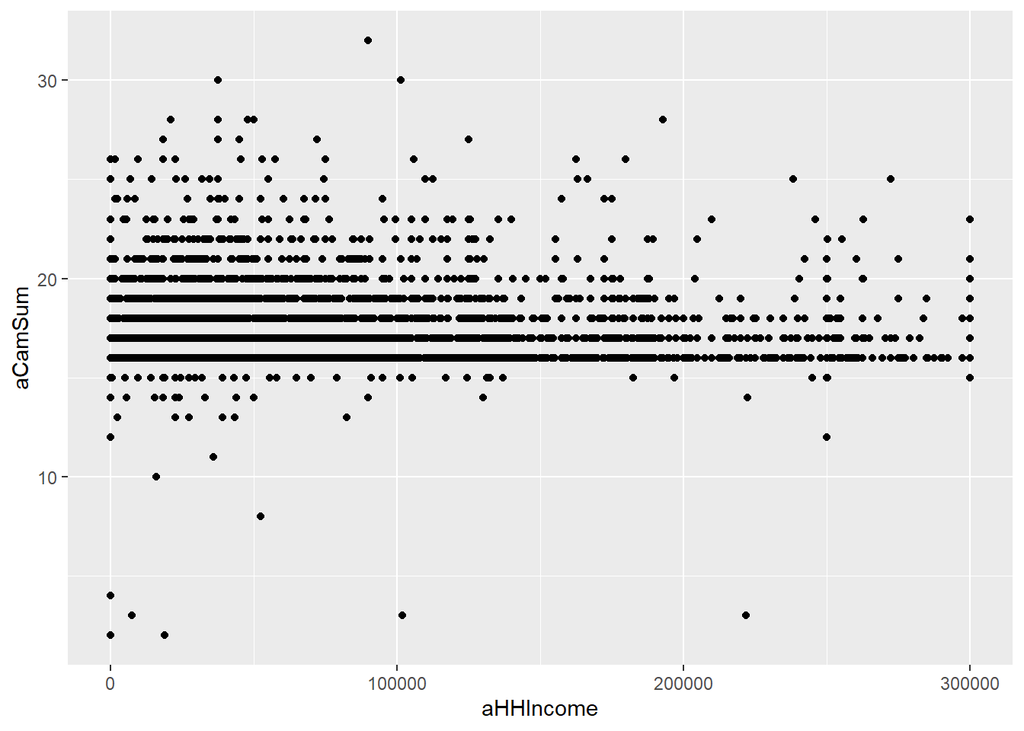

```
##
##  Pearson's product-moment correlation
##
## data:  x and y
## t = -0.9, df = 6084, p-value = 0.4
## alternative hypothesis: true correlation is not equal to 0
## 95 percent confidence interval:
##  -0.036  0.014
## sample estimates:
##    cor
## -0.011
```

### MIDUS 2

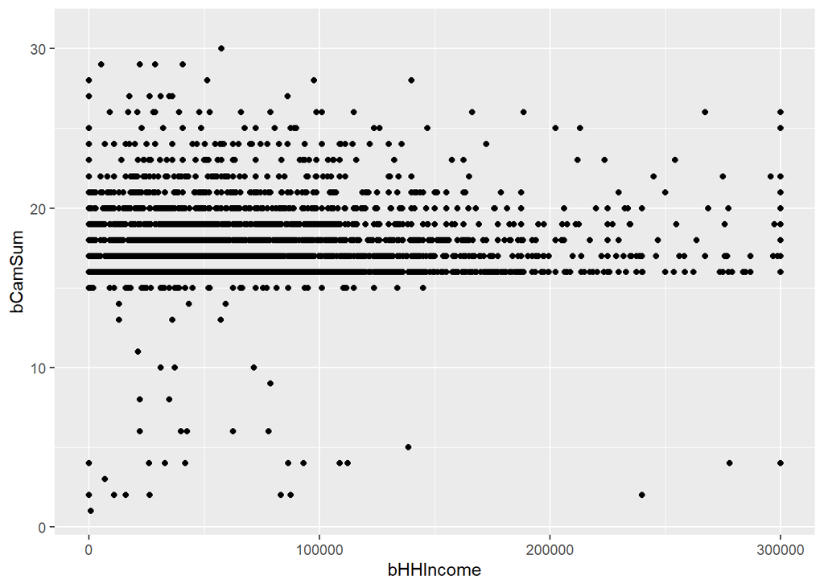

```
##
##  Pearson's product-moment correlation
##
## data:  x and y
## t = 1, df = 3829, p-value = 0.2
## alternative hypothesis: true correlation is not equal to 0
## 95 percent confidence interval:
##  -0.010  0.053
## sample estimates:
##   cor
## 0.022
```

### MIDUS 3

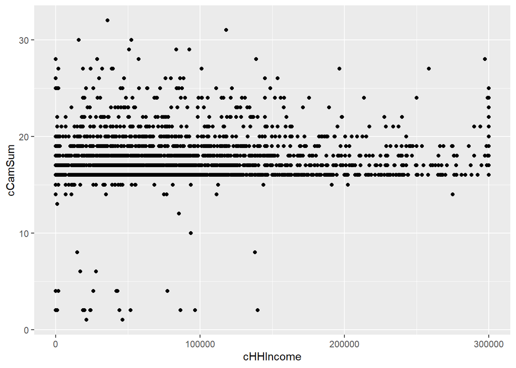

```
##
##  Pearson's product-moment correlation
##
## data:  x and y
## t = 4, df = 2690, p-value = 0.00004
## alternative hypothesis: true correlation is not equal to 0
## 95 percent confidence interval:
##  0.041 0.116
## sample estimates:
##   cor
## 0.079
```

## Education and CAMs

### MIDUS 1

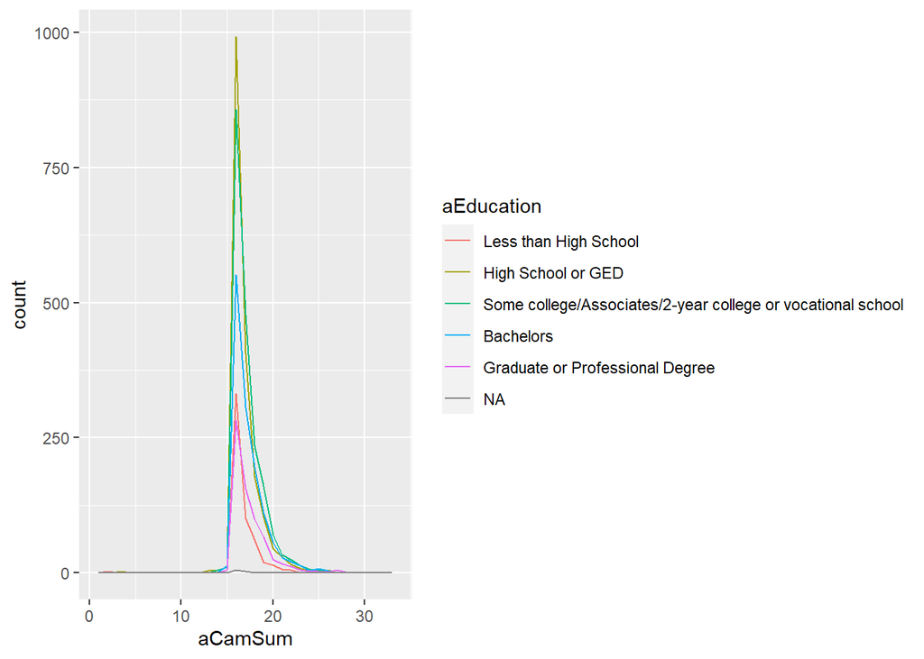

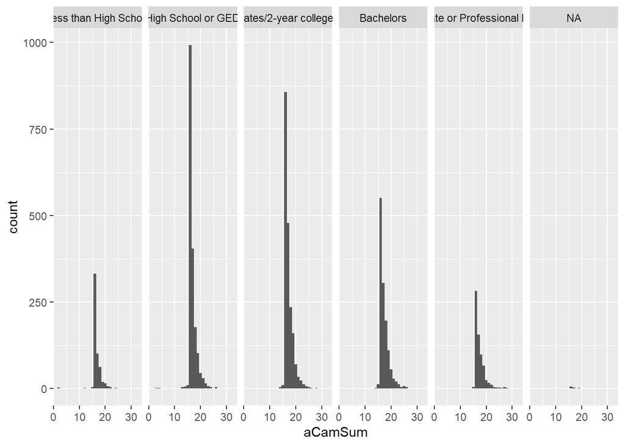

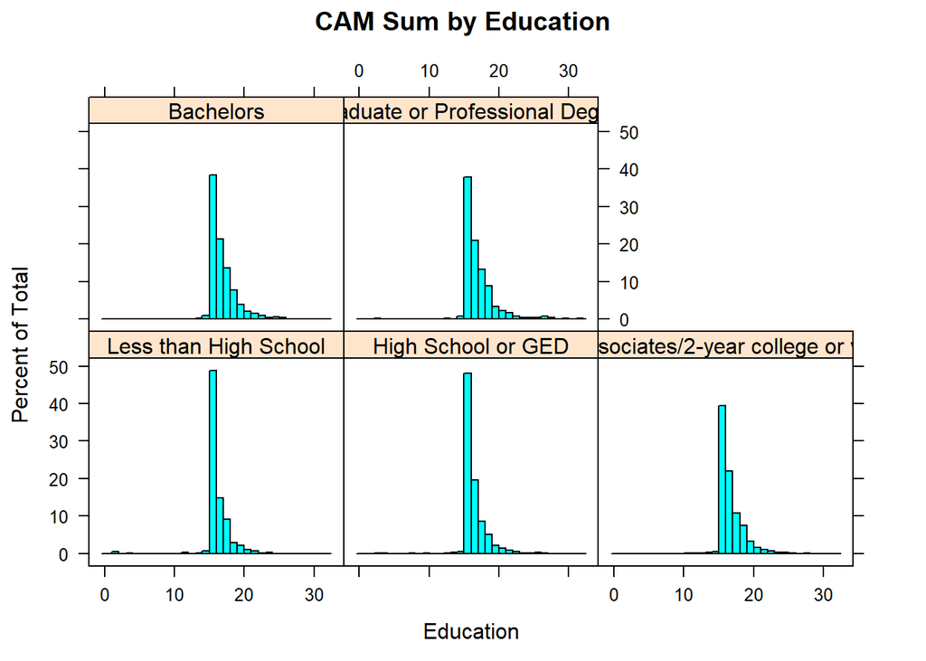